# Machine Learning Engineer Nanodegree

### Question 4

- Are there any data points considered outliers for more than one feature based on the definition above?
- Should these data points be removed from the dataset?
- If any data points were added to the `outliers` list to be removed, explain why.

**Hint:** If you have datapoints that are outliers in multiple categories think about why that may be and if they warrant removal. Also note how k-means is affected by outliers and whether or not this plays a factor in your analysis of whether or not to remove them.

```python
# For each feature find the data points with extreme high or low values
def get_outlier_indices(feature):

    # TODO: Calculate Q1 (25th percentile of the data) for the given feature
    Q1 = np.percentile(log_data[feature], 25)

    # TODO: Calculate Q3 (75th percentile of the data) for the given feature
    Q3 = np.percentile(log_data[feature], 75)

    # TODO: Use the interquartile range to calculate an outlier step (1.5 times the interquartile range)
    step = 1.5 * (Q3 - Q1)

    result = log_data[~((log_data[feature] >= Q1 - step) & (log_data[feature] <= Q3 + step))]

    indices = result.index

    # Display the outliers
#     print "Data points considered outliers for the feature '{}':".format(feature)
#     display(result)

    return indices

categories = np.array(log_data.columns)
outlier_crosstab = pd.DataFrame({}, columns=categories, index=categories)

for col in outlier_crosstab:
    for row in outlier_crosstab.index:
        outlier_crosstab.loc[row, col] = len(get_outlier_indices(col).intersection(get_outlier_indices(row)))

# # OPTIONAL: Select the indices for data points you wish to remove
# outliers  = [all_outlier_indices]
outliers = []

# # Remove the outliers, if any were specified
good_data = log_data.drop(log_data.index[outliers]).reset_index(drop = True)
```

```python
list_of_indexes = [get_outlier_indices(feature) for feature in log_data.columns]
all_outlier_indices = pd.Index(set())
for index in list_of_indexes:
    all_outlier_indices = all_outlier_indices.union(index)
```

**Answer:**

- Yes, see the table and heatmap below of a crosstabulation of outliers.
- I need more information to make this decision. I would like to see a table of standardized scores for each outlier before making my decision. If you look at the tables I produced below, it appears that these outliers are almost all composed of customers who happened to not buy many of one product in a year. This seems pretty normal, and I don't see anything crazy in the crosstabulation of outliers that makes me think that any need to be removed.
- NA.

Updated: See below that lists the 5 outlier indices present in multiple categories, along with the number and names of categories they're in. Also, I would note that choosing not to remove outliers may have an impact on both PCA and on the clustering algorithms used below (KMeans/GMM). Kmeans in particular will be sensitive. But, as we will see, this has no substantive impact on the success of the k=2 clustering implemented below.

```python
outlier_in_feature = lambda outlier_idx, feature: \
                    bool(outlier_idx in get_outlier_indices(feature))

result = {}
for outlier_idx in all_outlier_indices:
    result[outlier_idx] = []
    for feature in data.columns:
        if outlier_in_feature(outlier_idx, feature):
            result[outlier_idx].append(feature)
result_lists = pd.Series(result)
result = result_lists.apply(len)
print('The five outliers present in multiple categories:')
pd.DataFrame({
    'categories': result_lists[result > 1],
    'num_categories': result[result > 1],
})
```

```
The five outliers present in multiple categories:
```

|  | categories | num_categories |
| --- | --- | --- |
| 65 | [Fresh, Frozen] | 2 |
| 66 | [Fresh, Delicatessen] | 2 |
| 75 | [Grocery, Detergents_Paper] | 2 |
| 128 | [Fresh, Delicatessen] | 2 |
| 154 | [Milk, Grocery, Delicatessen] | 3 |

```python
outlier_crosstab
```

|  | Fresh | Milk | Grocery | Frozen | Detergents_Paper | Delicatessen |
| --- | --- | --- | --- | --- | --- | --- |
| Fresh | 16 | 0 | 0 | 1 | 0 | 2 |
| Milk | 0 | 4 | 1 | 0 | 0 | 1 |
| Grocery | 0 | 1 | 2 | 0 | 1 | 1 |
| Frozen | 1 | 0 | 0 | 10 | 0 | 0 |
| Detergents_Paper | 0 | 0 | 1 | 0 | 2 | 0 |
| Delicatessen | 2 | 1 | 1 | 0 | 0 | 14 |

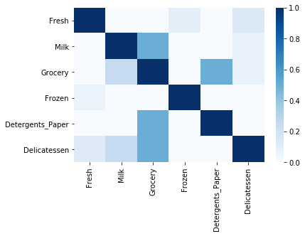

```python
sns.heatmap(outlier_crosstab / outlier_crosstab.max(), cmap='Blues')
```

```python
def get_outlier_standardized_scores(feature, data=log_data):

    scores = pd.Series(index=data.index)
    for element in get_outlier_indices(feature):
        score = ( log_data[feature].loc[element] - log_data[feature].mean() ) / log_data[feature].std()
        scores[element] = score

    return scores

#         print(scores)

standardized_outliers = pd.DataFrame({}, columns=log_data.columns, index=all_outlier_indices)
for feature in log_data.columns:
    standardized_outliers[feature].loc[get_outlier_indices(feature)] = get_outlier_standardized_scores(feature)
```

## Feature Transformation

In this section you will use principal component analysis (PCA) to draw conclusions about the underlying structure of the wholesale customer data. Since using PCA on a dataset calculates the dimensions which best maximize variance, we will find which compound combinations of features best describe customers.

### Implementation: PCA

Now that the data has been scaled to a more normal distribution and has had any necessary outliers removed, we can now apply PCA to the `good_data` to discover which dimensions about the data best maximize the variance of features involved. In addition to finding these dimensions, PCA will also report the *explained variance ratio* of each dimension — how much variance within the data is explained by that dimension alone. Note that a component (dimension) from PCA can be considered a new "feature" of the space, however it is a composition of the original features present in the data.

In the code block below, you will need to implement the following:

- Import `sklearn.decomposition.PCA` and assign the results of fitting PCA in six dimensions with `good_data` to `pca`.
- Apply a PCA transformation of `log_samples` using `pca.transform`, and assign the results to `pca_samples`.

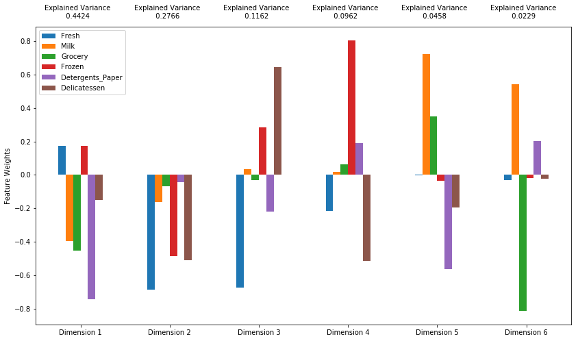

```python
from sklearn.decomposition import PCA

# TODO: Apply PCA by fitting the good data with the same number of dimensions as features
pca = PCA(n_components=6, random_state=10*42).fit(good_data)

# TODO: Transform log_samples using the PCA fit above
pca_samples = pca.transform(log_samples)

# Generate PCA results plot
pca_results = vs.pca_results(good_data, pca)
```

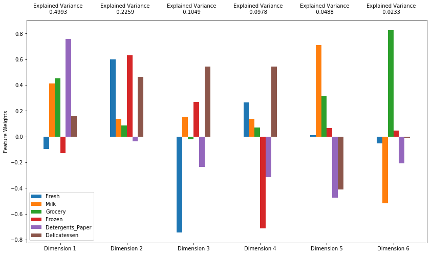

```python
from sklearn.decomposition import PCA

# TODO: Apply PCA by fitting the good data with the same number of dimensions as features
pca = PCA(n_components=6, random_state=10*42).fit(good_data.loc[ good_data.index.difference(all_outlier_indices) ])

# TODO: Transform log_samples using the PCA fit above
pca_samples = pca.transform(log_samples)

# Generate PCA results plot
pca_results = vs.pca_results(good_data.loc[ good_data.index.difference(all_outlier_indices) ], pca)
```

### Question 5

- How much variance in the data is explained **in total** by the first and second principal component?
- How much variance in the data is explained by the first four principal components?
- Using the visualization provided above, talk about each dimension and the cumulative variance explained by each, stressing upon which features are well represented by each dimension(both in terms of positive and negative variance explained). Discuss what the first four dimensions best represent in terms of customer spending.

**Hint:** A positive increase in a specific dimension corresponds with an *increase* of the *positive-weighted* features and a *decrease* of the *negative-weighted* features. The rate of increase or decrease is based on the individual feature weights.

**Answer:**

I would guess that each component could separate the following customers:

1. This one is composed mostly of `Detergents_Paper` and `Milk`/`Grocery`. We will recall that these variables were the most correlated set in the data, so it makes sense that they're in the first principal component. I'm not sure what customers would be well-separated by this dimension. Who buys a lot and not so much of these three types of goods? In particular, `Detergents_Paper`? Maybe there's some sort of magical cafe that allows you to do your laundry while you eat your food...Just kidding. I'm really not sure what groups would be separated by this data. If I had to make a guess, it would be a grocery store like Safeway or Vons, though they have much more than just these on their shelves.
2. The second dimension separates those who buy a lot of fresh, frozen, and delicatessen-type foods. This means that the food is being prepared and consumed on-site, so my guess is that this could be restaurants or cafes.
3. Probably actual delis, since they don't tend to have a lot of fresh food but a lot of delicatessen food. Could also be a cafe?
4. Again, this could be a real deli or cafe.

### Observation

Run the code below to see how the log-transformed sample data has changed after having a PCA transformation applied to it in six dimensions. Observe the numerical value for the first four dimensions of the sample points. Consider if this is consistent with your initial interpretation of the sample points.

```python
# Display sample log-data after having a PCA transformation applied
display(pd.DataFrame(np.round(pca_samples, 4), columns = pca_results.index.values))
```

|  | Dimension 1 | Dimension 2 | Dimension 3 | Dimension 4 | Dimension 5 | Dimension 6 |
| --- | --- | --- | --- | --- | --- | --- |
| 0 | 1.7793 | -0.6604 | -0.8247 | 1.6580 | 0.0903 | -0.4808 |
| 1 | 2.1793 | 0.5069 | 0.8243 | -1.0031 | -0.4516 | 0.3107 |
| 2 | 2.5291 | 1.3485 | 0.1094 | -0.2050 | -0.5879 | -0.0808 |

### Implementation: Dimensionality Reduction

When using principal component analysis, one of the main goals is to reduce the dimensionality of the data — in effect, reducing the complexity of the problem. Dimensionality reduction comes at a cost: Fewer dimensions used implies less of the total variance in the data is being explained. Because of this, the *cumulative explained variance ratio* is extremely important for knowing how many dimensions are necessary for the problem. Additionally, if a signifiant amount of variance is explained by only two or three dimensions, the reduced data can be visualized afterwards.

In the code block below, you will need to implement the following:

- Assign the results of fitting PCA in two dimensions with `good_data` to `pca`.
- Apply a PCA transformation of `good_data` using `pca.transform`, and assign the results to `reduced_data`.
- Apply a PCA transformation of `log_samples` using `pca.transform`, and assign the results to `pca_samples`.

```python
# TODO: Apply PCA by fitting the good data with only two dimensions
pca = PCA(2).fit(good_data)

# TODO: Transform the good data using the PCA fit above
reduced_data = pca.transform(good_data)

# TODO: Transform log_samples using the PCA fit above
pca_samples = pca.transform(log_samples)

# Create a DataFrame for the reduced data
reduced_data = pd.DataFrame(reduced_data, columns = ['Dimension 1', 'Dimension 2'])
```

### Observation

```python
# Display sample log-data after applying PCA transformation in two dimensions
display(pd.DataFrame(np.round(pca_samples, 4), columns = ['Dimension 1', 'Dimension 2']))
```

|  | Dimension 1 | Dimension 2 |
| --- | --- | --- |
| 0 | -1.7510 | -0.0705 |
| 1 | -2.1162 | -0.7488 |
| 2 | -2.3702 | -1.7971 |

## Visualizing a Biplot

A biplot is a scatterplot where each data point is represented by its scores along the principal components. The axes are the principal components (in this case `Dimension 1` and `Dimension 2`). In addition, the biplot shows the projection of the original features along the components. A biplot can help us interpret the reduced dimensions of the data, and discover relationships between the principal components and original features.

Run the code cell below to produce a biplot of the reduced-dimension data.

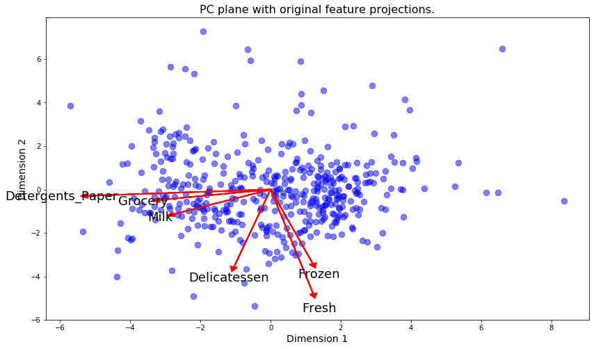

```python
# Create a biplot
vs.biplot(good_data, reduced_data, pca)
```

### Observation

From the biplot, which of the original features are most strongly correlated with the first component? What about those that are associated with the second component? Do these observations agree with the pca_results plot you obtained earlier?

**Yes, the results agree. `Detergents_Paper`, `Grocery`, and `Milk` are most associated with Dimension 1, as displayed in the plots above. Likewise for the other variables.**

## Clustering

In this section, you will choose to use either a K-Means clustering algorithm or a Gaussian Mixture Model clustering algorithm to identify the various customer segments hidden in the data. You will then recover specific data points from the clusters to understand their significance by transforming them back into their original dimension and scale.

### Question 6

- What are the advantages to using a K-Means clustering algorithm?
- What are the advantages to using a Gaussian Mixture Model clustering algorithm?
- Given your observations about the wholesale customer data so far, which of the two algorithms will you use and why?

**Hint:** Think about the differences between hard clustering and soft clustering and which would be appropriate for our dataset.

**Answer:**

- K-Means clustering has a number of advantages. The algorithm takes a k value representing the number of clusters to identify, and assigns a concrete cluster prediction to each point in the feature space. The algorithm tends to produce globular clusters, meaning that the cluster boundaries form a convex set. ([source](http://www.improvedoutcomes.com/docs/WebSiteDocs/Clustering/K-Means_Clustering_Overview.htm)). The algorithm is also simple and fast, but it can be sensitive to outliers, unable to detect more complex structures, and is not deterministic -- the end result can be influenced by the random initalized means. Finally, kmeans may get stuck in a local optimum. ([source](https://www.quora.com/What-are-the-advantages-of-K-Means-clustering))
- Gaussian mixture models are a [generalization of k-means](http://scikit-learn.org/stable/modules/mixture.html) that incorporate information about the (co)variance structure of the data. A GMM assumes that the data come from a set of multivariate normal distributions with unknown parameters, and estimates the parameters of these distributions based on the data. GMMs are thus a generalization of KMeans that take into account covariance, allowing for the identification of globular clusters with different shapes and variances. According to the sklearn documentation, it's also one of the fastes mixture models to learn. Finally, since the GMM approach includes models, we can estimate the probability that a point is in any given cluster.
- I'll use GMM because it seems to be more flexible than KMeans (soft clustering vs. hard). There are some significant differences in both the variance and covariance structure of our data: Some variables are more variable, and some are more correlated with each other than others, so the GMM approach should work reasonably well. This problem doesn't have obvious clusters based on our EDA, so a soft clustering approach is probably better.

### Implementation: Creating Clusters

Depending on the problem, the number of clusters that you expect to be in the data may already be known. When the number of clusters is not known *a priori*, there is no guarantee that a given number of clusters best segments the data, since it is unclear what structure exists in the data — if any. However, we can quantify the "goodness" of a clustering by calculating each data point's *silhouette coefficient*. The [silhouette coefficient](http://scikit-learn.org/stable/modules/generated/sklearn.metrics.silhouette_score.html) for a data point measures how similar it is to its assigned cluster from -1 (dissimilar) to 1 (similar). Calculating the *mean* silhouette coefficient provides for a simple scoring method of a given clustering.

In the code block below, you will need to implement the following:

- Fit a clustering algorithm to the `reduced_data` and assign it to `clusterer`.
- Predict the cluster for each data point in `reduced_data` using `clusterer.predict` and assign them to `preds`.
- Find the cluster centers using the algorithm's respective attribute and assign them to `centers`.
- Predict the cluster for each sample data point in `pca_samples` and assign them `sample_preds`.
- Import `sklearn.metrics.silhouette_score` and calculate the silhouette score of `reduced_data` against `preds`.
  - Assign the silhouette score to `score` and print the result.

```python
from sklearn.mixture import GaussianMixture
from sklearn.metrics import silhouette_score

def get_silhouette_score(n_components, data=reduced_data, samples=None):

    # TODO: Apply your clustering algorithm of choice |to the reduced data
    clusterer = GaussianMixture(n_components=n_components)
    clusterer.fit(data)

    # TODO: Predict the cluster for each data point
    preds = clusterer.predict(data)

    # TODO: Find the cluster centers
    centers = clusterer.means_

    # TODO: Predict the cluster for each transformed sample data point
    sample_preds = clusterer.predict(samples) if samples is not None else None

    # TODO: Calculate the mean silhouette coefficient for the number of clusters chosen
    score = silhouette_score(data, preds)
    return score

scores = {
    2: list(),
    3: list(),
    4: list(),
    5: list(),
    10: list(),
    25: list(),
    50: list(),
    100: list()
}

for n in scores.keys():
    for i in range(10):
        scores[n].append(get_silhouette_score(n))
```

```python
for n in scores:
    scores[n] = np.array(scores[n]).mean()
scores
```

```
{2: 0.41023891957909964,
 3: 0.39627310320001941,
 4: 0.31732650234542337,
 5: 0.27638328421565106,
 10: 0.31283101702532135,
 25: 0.28319317085246387,
 50: 0.26775259115736333,
 100: 0.32377709988309294}
```

### Question 7

- Report the silhouette score for several cluster numbers you tried.
- Of these, which number of clusters has the best silhouette score?

**Answer:**

UPDATE: After removing the accidental hard-coding in the get_silhouette_score function above, I found that k=2 or k=3 is optimal. Since it's what I chose originally and now know to be the correct value, we'll stick with 2. I also ran the clustering again, and found that k=2 was even more obviously the correct value. So maybe we should just make it a policy to remove outliers! But only for the purpose of estimating clusters.

```python
# TODO: Apply your clustering algorithm of choice |to the reduced data
clusterer = GaussianMixture(n_components=2)
clusterer.fit(reduced_data)

# TODO: Predict the cluster for each data point
preds = clusterer.predict(reduced_data)

# TODO: Find the cluster centers
centers = clusterer.means_

# TODO: Predict the cluster for each transformed sample data point
sample_preds = clusterer.predict_proba(pca_samples)

# TODO: Calculate the mean silhouette coefficient for the number of clusters chosen
score = silhouette_score(reduced_data, preds)
```

### Cluster Visualization

Once you've chosen the optimal number of clusters for your clustering algorithm using the scoring metric above, you can now visualize the results by executing the code block below. Note that, for experimentation purposes, you are welcome to adjust the number of clusters for your clustering algorithm to see various visualizations. The final visualization provided should, however, correspond with the optimal number of clusters.

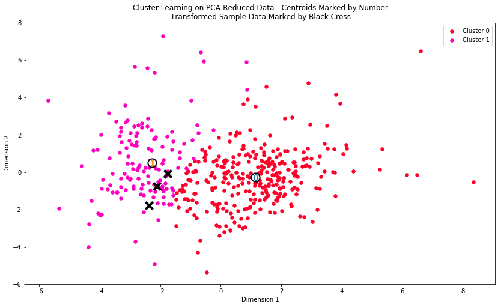

```python
# Display the results of the clustering from implementation
vs.cluster_results(reduced_data, preds, centers, pca_samples)
```

```python
# # TODO: Apply your clustering algorithm of choice |to the reduced data
# clusterer = GaussianMixture(n_components=3)
# clusterer.fit(reduced_data)

# # TODO: Predict the cluster for each data point
# preds1 = clusterer.predict(reduced_data)

# # TODO: Find the cluster centers
# centers1 = clusterer.means_

# # TODO: Predict the cluster for each transformed sample data point
# sample_preds = clusterer.predict_proba(pca_samples)

# # TODO: Calculate the mean silhouette coefficient for the number of clusters chosen
# score = silhouette_score(reduced_data, preds)

# # Display the results of the clustering from implementation
# vs.cluster_results(reduced_data, preds1, centers1, pca_samples)
```

### Implementation: Data Recovery

Each cluster present in the visualization above has a central point. These centers (or means) are not specifically data points from the data, but rather the *averages* of all the data points predicted in the respective clusters. For the problem of creating customer segments, a cluster's center point corresponds to *the average customer of that segment*. Since the data is currently reduced in dimension and scaled by a logarithm, we can recover the representative customer spending from these data points by applying the inverse transformations.

In the code block below, you will need to implement the following:

- Apply the inverse transform to `centers` using `pca.inverse_transform` and assign the new centers to `log_centers`.
- Apply the inverse function of `np.log` to `log_centers` using `np.exp` and assign the true centers to `true_centers`.

```python
# TODO: Inverse transform the centers
log_centers = pca.inverse_transform(centers)

# TODO: Exponentiate the centers
true_centers = np.exp(log_centers)

# Display the true centers
segments = ['Segment {}'.format(i) for i in range(0,len(centers))]
true_centers = pd.DataFrame(np.round(true_centers), columns = data.keys())
true_centers.index = segments
display(true_centers)
```

|  | Fresh | Milk | Grocery | Frozen | Detergents_Paper | Delicatessen |
| --- | --- | --- | --- | --- | --- | --- |
| Segment 0 | 9029.0 | 2229.0 | 2798.0 | 2051.0 | 380.0 | 754.0 |
| Segment 1 | 2939.0 | 7576.0 | 12536.0 | 781.0 | 4702.0 | 848.0 |

### Question 8

- Consider the total purchase cost of each product category for the representative data points above, and reference the statistical description of the dataset at the beginning of this project(specifically looking at the mean values for the various feature points). What set of establishments could each of the customer segments represent?

**Hint:** A customer who is assigned to `'Cluster X'` should best identify with the establishments represented by the feature set of `'Segment X'`. Think about what each segment represents in terms their values for the feature points chosen. Reference these values with the mean values to get some perspective into what kind of establishment they represent.

```python
true_centers - data.mean()
```

|  | Fresh | Milk | Grocery | Frozen | Detergents_Paper | Delicatessen |
| --- | --- | --- | --- | --- | --- | --- |
| Segment 0 | -2971.297727 | -3567.265909 | -5153.277273 | -1020.931818 | -2501.493182 | -770.870455 |
| Segment 1 | -9061.297727 | 1779.734091 | 4584.722727 | -2290.931818 | 1820.506818 | -676.870455 |

**Answer:**

```python
true_centers / data.mean()
```

|  | Fresh | Milk | Grocery | Frozen | Detergents_Paper | Delicatessen |
| --- | --- | --- | --- | --- | --- | --- |
| Segment 0 | 0.752398 | 0.384558 | 0.351893 | 0.667658 | 0.131876 | 0.494468 |
| Segment 1 | 0.244911 | 1.307048 | 1.576602 | 0.254237 | 1.631793 | 0.556113 |

```python
reduced_data\
    .join(pd.DataFrame(preds))\
    .rename({0: 'preds'}, axis=1)\
    .groupby('preds')\
    .mean()
```

| preds | Dimension 1 | Dimension 2 |
| --- | --- | --- |
| 0 | 1.180076 | -0.263241 |
| 1 | -2.528733 | 0.564089 |

### Question 9

- For each sample point, which customer segment from **Question 8** best represents it?
- Are the predictions for each sample point consistent with this?*

Run the code block below to find which cluster each sample point is predicted to be.

```python
true_centers
```

|  | Fresh | Milk | Grocery | Frozen | Detergents_Paper | Delicatessen |
| --- | --- | --- | --- | --- | --- | --- |
| Segment 0 | 9029.0 | 2229.0 | 2798.0 | 2051.0 | 380.0 | 754.0 |
| Segment 1 | 2939.0 | 7576.0 | 12536.0 | 781.0 | 4702.0 | 848.0 |

```python
# Display the predictions
for i, pred in enumerate(sample_preds):
    print "Sample point", i, "predicted to be in Cluster", pred
```

```
Sample point 0 predicted to be in Cluster [ 0.2800436  0.7199564]
Sample point 1 predicted to be in Cluster [ 0.24731999  0.75268001]
Sample point 2 predicted to be in Cluster [ 0.25611412  0.74388588]
```

```python
samples.mean() / data.mean()
```

```
Fresh               0.767453
Milk                1.313374
Grocery             1.369969
Frozen              0.853535
Detergents_Paper    1.930249
Delicatessen        1.335851
dtype: float64
```

```python
true_centers / data.mean()
```

|  | Fresh | Milk | Grocery | Frozen | Detergents_Paper | Delicatessen |
| --- | --- | --- | --- | --- | --- | --- |
| Segment 0 | 0.752398 | 0.384558 | 0.351893 | 0.667658 | 0.131876 | 0.494468 |
| Segment 1 | 0.244911 | 1.307048 | 1.576602 | 0.254237 | 1.631793 | 0.556113 |

**Answer:**

- Based on the printout above and the plot showing with black `X`s each sample point, they are all in Segment 1, but somewhat close to the boundary. In fact, each one is predicted to be in Segment 1 with about 72-75% chance. Thus, since our hard prediction is the argmax of the probabilities predicted, our prediction is Segment 1 for these points.
- Yes, see above. Each point is predicted with probability about 0.72-0.75 to be in Segment 1, so we predict them to be in Segment 1.

## Conclusion

In this final section, you will investigate ways that you can make use of the clustered data. First, you will consider how the different groups of customers, the *customer segments*, may be affected differently by a specific delivery scheme. Next, you will consider how giving a label to each customer (which *segment* that customer belongs to) can provide for additional features about the customer data. Finally, you will compare the *customer segments* to a hidden variable present in the data, to see whether the clustering identified certain relationships.

### Question 10

Companies will often run [A/B tests](https://en.wikipedia.org/wiki/A/B_testing) when making small changes to their products or services to determine whether making that change will affect its customers positively or negatively. The wholesale distributor is considering changing its delivery service from currently 5 days a week to 3 days a week. However, the distributor will only make this change in delivery service for customers that react positively.

- How can the wholesale distributor use the customer segments to determine which customers, if any, would react positively to the change in delivery service?*

**Hint:** Can we assume the change affects all customers equally? How can we determine which group of customers it affects the most?

**Answer:**

- Changing the delivery from 5 days a week to 3 days a week will probably most impact customers who buy a lot of `Fresh`, `Milk`, and possibly `Grocery`. This is because these deliveries are most time-sensitive, so a more periodic delivery schedule could cause difficulties for these customers if they aren't prepared to handle it because of storage practices or other considerations. It isn't immediately clear how this might impact our two identified segments differently, since both groups include customers who buy a lot of perishable food. That being said, Segment 0 is more likely to buy `Fresh`, which is *most* likely to be affected, so these customers are probably least likely to like this change, and some special attention should be paid to these customers if the change moves forward.

Update: To run an A/B test:

- Randomly select some customers to participate in a trial program. We can calculate the sample size required to detect a difference of given magnitude, using power. The power of a hypothesis test will return the probability of detecting a given difference -- for example, we could calculate the necessary sample size using power for given p-value and size of the difference of means. In other words, we could calculate the sample size required to detect a difference of one unit on our metric of choice, say mean satisfcation, at 95% confidence. Randomly assign some of these to the experimental condition (3-day deliver) and some to the control (5-day deliver). Gather data during the trial on customers' satisfaction with their delivery, as well as other metrics of interest. Perform a t-test on these metrics to understand if there is a statistically-significant difference. If so, the experimental condition had an effect and we can infer the sign of the effect.

UPDATE: To incorporate the clusters in the A/B test above, we would need to sample customers from both clusters we identified. Then we can investigate not only whether customers in general react positively to it, but also whether our identified customer segments react differently. In particular, we would perform a test of the statistical significance of difference of means, where for each group we calculate the mean of their difference score, where the difference score is the change in their satisfaction when presented with the new delivery schedule.

### Question 11

Additional structure is derived from originally unlabeled data when using clustering techniques. Since each customer has a *customer segment* it best identifies with (depending on the clustering algorithm applied), we can consider *'customer segment'* as an **engineered feature** for the data. Assume the wholesale distributor recently acquired ten new customers and each provided estimates for anticipated annual spending of each product category. Knowing these estimates, the wholesale distributor wants to classify each new customer to a *customer segment* to determine the most appropriate delivery service.

- How can the wholesale distributor label the new customers using only their estimated product spending and the **customer segment** data?

**Hint:** A supervised learner could be used to train on the original customers. What would be the target variable?

**Answer:**

- In this case I would probably just use the log/PCA transformed sample to predict the class based on our GMM clusterer used above. As mentioned in the hint above, however, we could train a supervised learner on the data and make the prediction in this way. The target variable in this case would be the (categorical) cluster group, so we could use binary logistic regression or almost any other classifier. This would allow us to automatically classify a new customer into one of our two clusters.

### Visualizing Underlying Distributions

At the beginning of this project, it was discussed that the `'Channel'` and `'Region'` features would be excluded from the dataset so that the customer product categories were emphasized in the analysis. By reintroducing the `'Channel'` feature to the dataset, an interesting structure emerges when considering the same PCA dimensionality reduction applied earlier to the original dataset.

Run the code block below to see how each data point is labeled either `'HoReCa'` (Hotel/Restaurant/Cafe) or `'Retail'` the reduced space. In addition, you will find the sample points are circled in the plot, which will identify their labeling.

### Question 12

- How well does the clustering algorithm and number of clusters you've chosen compare to this underlying distribution of Hotel/Restaurant/Cafe customers to Retailer customers?
- Are there customer segments that would be classified as purely 'Retailers' or 'Hotels/Restaurants/Cafes' by this distribution?
- Would you consider these classifications as consistent with your previous definition of the customer segments?

**Answer:**

- I'm actually amazed that there *was* an underlying structure here, since this obviously contradicts my conclusion above that the data didn't have a lot of internal structure based on the uniform mean silhouette scores I observed, independent of the number of clusterd identified. It was quite fortunate that I arbitrarily chose 2 as the cluster number, since this corresponds to the actual structure. In short, our clustering was actually quite successful at detecting this underlying structure.
- Sure. There is a fuzzy boundary region following about a vertical line at Dimension1~=-0.5, and to the left and right of this there are pretty clear clusters without much mixing.
- Yes! The plots are surprisingly similar:

UPDATE: Obviously, had I correctly implemented the get_silhouette_score function, I wouldn't have been surprised about there being two clusters.

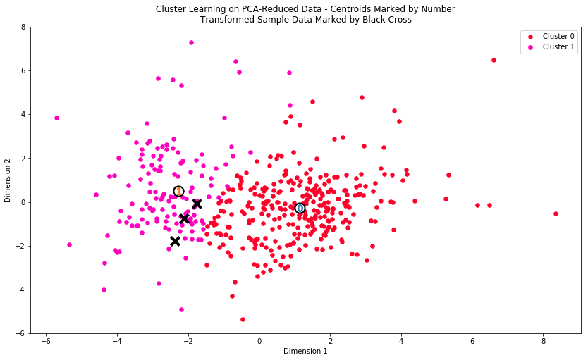

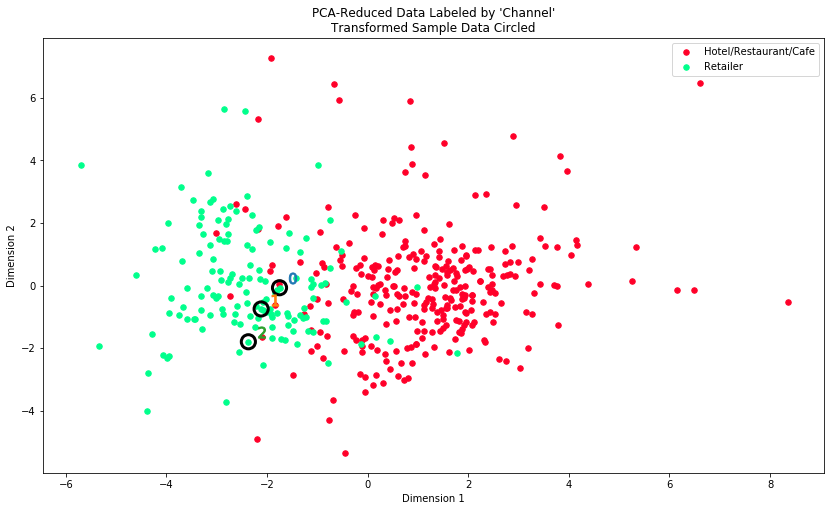

```python
vs.cluster_results(reduced_data, preds, centers, pca_samples)
vs.channel_results(reduced_data, outliers, pca_samples)
```

> **Note**: Once you have completed all of the code implementations and successfully answered each question above, you may finalize your work by exporting the iPython Notebook as an HTML document. You can do this by using the menu above and navigating to  
> **File -> Download as -> HTML (.html)**. Include the finished document along with this notebook as your submission.